# Personalysis and Strength Profile - Clinical Analytics

[figure not shown]

[figure not shown]

**Respondents:** Amir Ali, Andrew Bennett, Angelique Russell, Ari Robicsek, Ashley Snoddy, Bradley Roberts, Brian Penny, Caleb Stowell, Chris Kim, Chuck Laurenson, Devendra Manandhar, Firouzeh Manucheri, Ford Parsons, Funi Chen, Gino Conconi, Jacob Lippa, Jacob VanderKam, Jason Muller, Jessica Quinn, Jessica Swann, Jodi Brekhus, John Madden, Jonathn Patten, Kevin Dombek, Keyana Azari, Laurel Kirby, Linda Doan-Huynh, Lizbeth McNeil, Mauli Modi, Ngoc Salvatierra, Pete Firth, Rocky Ramos, Said Sariolghalam, Sarah Nurse, Steve Tarkalson, Susan Hermanto, Susan Pollock, Suzanne Campbell, Thomas French, Thomas Gonzalez, Tony Recalde, Troy Hanninen, Vandana Kapoor

**Update:** 04 February, 2021 (T. French)

# Personalysis

[figure not shown]

## Amir

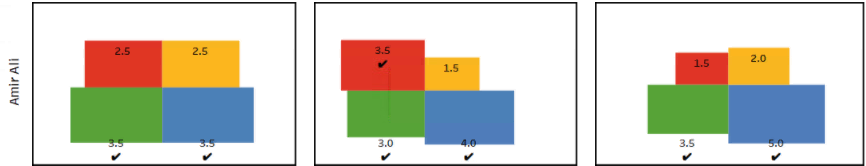

## Andy

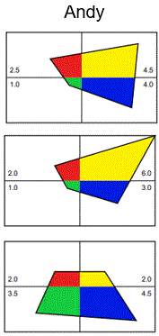

## Angelique

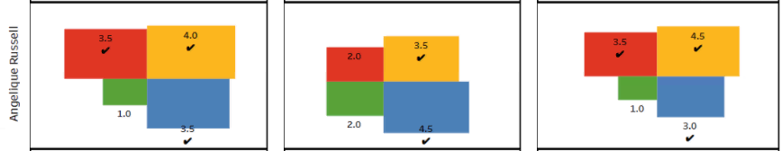

## Ari

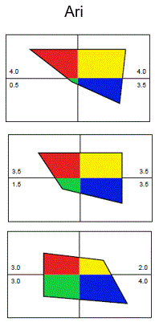

## Ashley

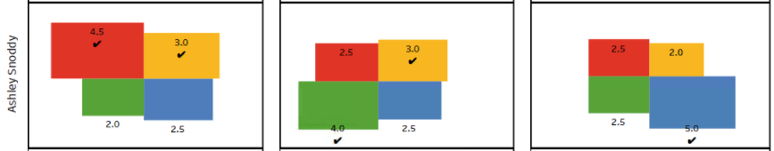

## Brad

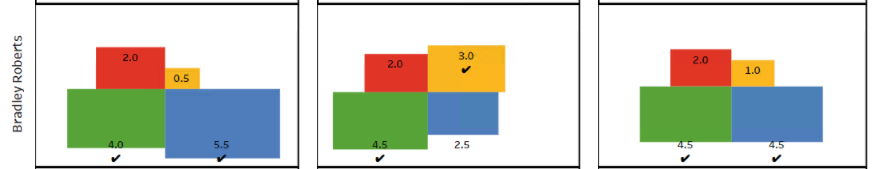

## Brian

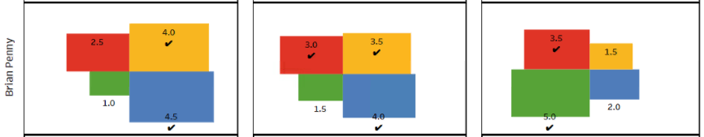

## Caleb

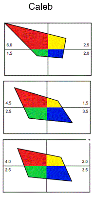

## Chris

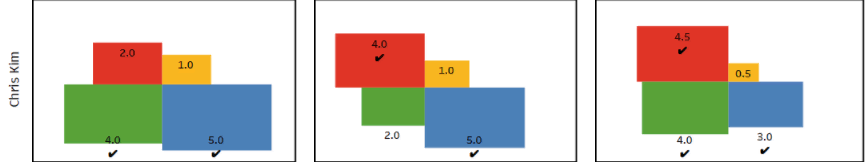

## Chuck

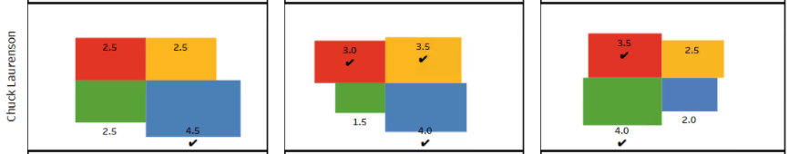

## Devendra

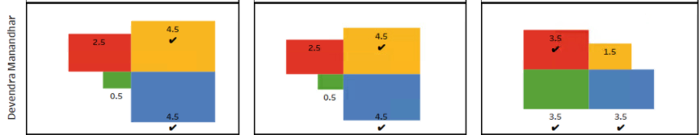

## Funi

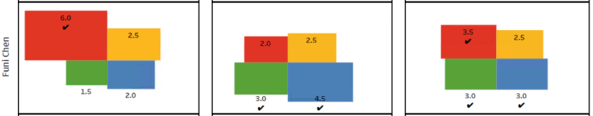

## Gino

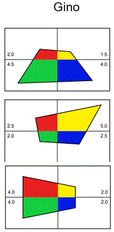

## Firouzeh

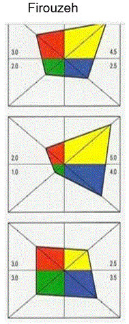

## Ford

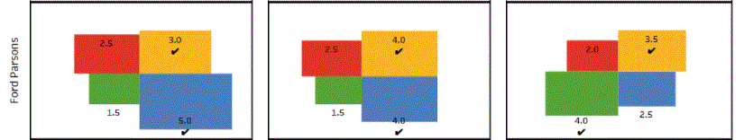

## Jacob

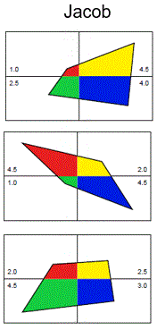

### Jake

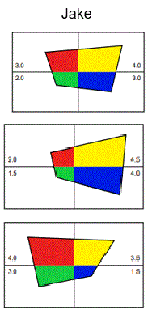

## Jason

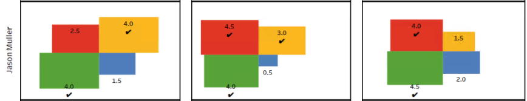

## Jessica Q

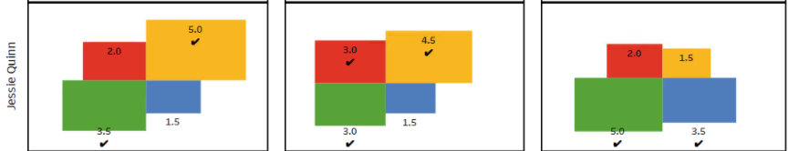

### Jessica S

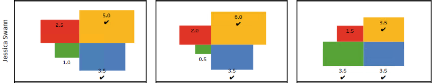

## Jodi

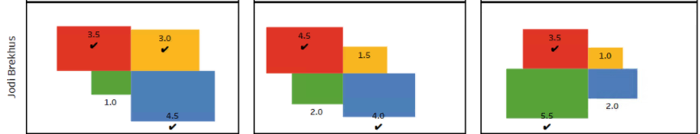